# 08_feature_ablation

Andrea Polazzi

2026-03-19

# Setup

## Prepare dataset

```r
library(readxl)
library(tidyverse)
```

```r
library(ggplot2)
library(caret)
library(dplyr)
source('../scripts/clean_columns.R')

data <- read_xlsx('../data/raw/PCAWG_variables_PCA_woK.xlsx')
clean_data <- clean_pcawg_data(data)
model_data <- clean_data[complete.cases(clean_data), -c(1,2)]
model_data$alt_status <- factor(model_data$alt_status, levels=c("ALT-low","ALT-high"), labels = c("ALT_low","ALT_high"))
summary(model_data)
```

```
##     alt_status     tf_rate         telomere_insertion_rate
##  ALT_low :768   Min.   : 0.00000   Min.   :0.00000
##  ALT_high: 49   1st Qu.: 0.00000   1st Qu.:0.00000
##                 Median : 0.03147   Median :0.00000
##                 Mean   : 0.12777   Mean   :0.03592
##                 3rd Qu.: 0.07243   3rd Qu.:0.01934
##                 Max.   :19.73776   Max.   :3.46027
##  telomere_content_log2   TERT_FPKM        ATAGGG_singleton_dist
##  Min.   :-2.29092      Min.   : 0.00000   Min.   :-3.82135
##  1st Qu.:-0.95324      1st Qu.: 0.02014   1st Qu.:-0.56491
##  Median :-0.55712      Median : 0.10907   Median : 0.02487
##  Mean   :-0.44621      Mean   : 0.91717   Mean   : 0.01321
##  3rd Qu.:-0.08914      3rd Qu.: 0.39077   3rd Qu.: 0.59111
##  Max.   : 3.84469      Max.   :53.76790   Max.   : 4.47470
##  CTAGGG_singleton_dist GTAGGG_singleton_dist TAAGGG_singleton_dist
##  Min.   :-3.0401       Min.   :-2.43840      Min.   :-3.13241
##  1st Qu.:-0.2686       1st Qu.:-0.32314      1st Qu.:-0.53764
##  Median : 0.1495       Median : 0.03610      Median : 0.10627
##  Mean   : 0.1797       Mean   : 0.03857      Mean   : 0.07596
##  3rd Qu.: 0.6213       3rd Qu.: 0.33915      3rd Qu.: 0.69820
##  Max.   : 2.8541       Max.   : 2.74981      Max.   : 3.81679
##  TCAGGG_singleton_dist TGAGGG_singleton_dist TTCGGG_singleton_dist
##  Min.   :-2.8553       Min.   :-5.27154      Min.   :-3.23509
##  1st Qu.:-0.4778       1st Qu.:-0.35882      1st Qu.:-0.48603
##  Median : 0.1182       Median : 0.07551      Median : 0.09028
##  Mean   : 0.1982       Mean   : 0.10597      Mean   : 0.15567
##  3rd Qu.: 0.7847       3rd Qu.: 0.46824      3rd Qu.: 0.66142
##  Max.   : 7.5686       Max.   : 6.67267      Max.   : 8.73932
##  TTGGGG_singleton_dist TTTGGG_singleton_dist
##  Min.   :-3.02421      Min.   :-3.80780
##  1st Qu.:-0.36756      1st Qu.:-0.40600
##  Median :-0.01286      Median : 0.02340
##  Mean   : 0.02180      Mean   : 0.00976
##  3rd Qu.: 0.44543      3rd Qu.: 0.48155
##  Max.   : 3.19366      Max.   : 2.25362
```

## Define feature sets

```r
feature_sets <- list(
  full = model_data,
  no_tel_insert = model_data[, !names(model_data) %in% "telomere_insertion_rate"],
  no_tf = model_data[, !names(model_data) %in% "tf_rate"],
  no_TERT = model_data[, !names(model_data) %in% "TERT_FPKM"],
  no_tel_content = model_data[, !names(model_data) %in% "telomere_content_log2"],
  no_TVRs = model_data[, -c(grep('singleton', names(model_data), ))]
)
```

## CV setup

```r
set.seed(21)
folds <- createMultiFolds(model_data$alt_status, k = 5, times = 20)

ctrl <- trainControl(
  method = "repeatedcv",
  number = 5,
  repeats = 20,
  index = folds,
  classProbs = TRUE,
  summaryFunction = twoClassSummary,
  savePredictions = 'final'
)
```

# Train models

```r
library(caret)
library(pROC)
library(dplyr)
library(randomForest)

results <- data.frame()
all_resamples <- list()

for (fs in names(feature_sets)) {

  df <- feature_sets[[fs]]

  log_model <- train(
    alt_status ~ .,
    data = df,
    method = "glm",
    family = "binomial",
    metric = "ROC",
    trControl = ctrl
  )

  rf_model <- train(
    alt_status ~ .,
    data = df,
    method = "rf",
    metric = "ROC",
    trControl = ctrl
  )

  models <- list(LogReg = log_model, RF = rf_model)

  for (m in names(models)) {

    model <- models[[m]]

    rs <- model$resample

    rs$feature_set <- fs
    rs$model <- m

    all_resamples[[paste(fs, m, sep = "_")]] <- rs

    results <- rbind(
      results,
      data.frame(
        feature_set = fs,
        model = m,
        mean_AUC = mean(rs$ROC, na.rm = TRUE),
        sd_AUC = sd(rs$ROC, na.rm = TRUE),
        mean_sensitivity = mean(rs$Sens, na.rm = TRUE),
        mean_specificity = mean(rs$Spec, na.rm = TRUE)
      )
    )
  }
}

results <- results %>%
  group_by(model) %>%
  mutate(
    delta_AUC = mean_AUC - mean_AUC[feature_set == "full"]
  ) %>%
  ungroup()

print(results, n = 12)
```

```
## # A tibble: 12 × 7
##    feature_set model mean_AUC sd_AUC mean_sensitivity mean_specificity delta_AUC
##    <chr>       <chr>    <dbl>  <dbl>            <dbl>            <dbl>     <dbl>
##  1 full        LogR…    0.946 0.0744            0.990            0.827   0
##  2 full        RF       0.983 0.0139            0.999            0.642   0
##  3 no_tel_ins… LogR…    0.898 0.0641            0.995            0.618  -4.84e-2
##  4 no_tel_ins… RF       0.921 0.0607            0.991            0.654  -6.14e-2
##  5 no_tf       LogR…    0.960 0.0689            0.990            0.834   1.43e-2
##  6 no_tf       RF       0.983 0.0150            0.999            0.667  -6.79e-5
##  7 no_TERT     LogR…    0.931 0.0873            0.990            0.783  -1.52e-2
##  8 no_TERT     RF       0.982 0.0149            0.999            0.643  -1.01e-3
##  9 no_tel_con… LogR…    0.947 0.0774            0.990            0.825   6.24e-4
## 10 no_tel_con… RF       0.985 0.0125            0.999            0.654   2.40e-3
## 11 no_TVRs     LogR…    0.883 0.0778            0.996            0.631  -6.32e-2
## 12 no_TVRs     RF       0.898 0.0625            0.996            0.618  -8.44e-2
```

# Plots

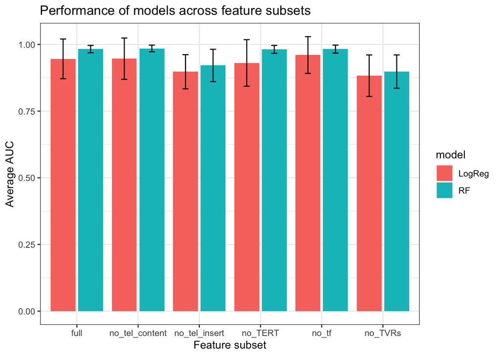

```r
ggplot(results, aes(x = feature_set, y = mean_AUC, fill = model)) +
  geom_col(position = position_dodge2()) +
  geom_errorbar(
    aes(ymin = mean_AUC - sd_AUC, ymax = mean_AUC + sd_AUC),
    position = position_dodge(width = 0.9),
    width = 0.2
  ) +
  theme_bw()+
  labs(x='Feature subset',
       y='Average AUC',
       title='Performance of models across feature subsets')
```

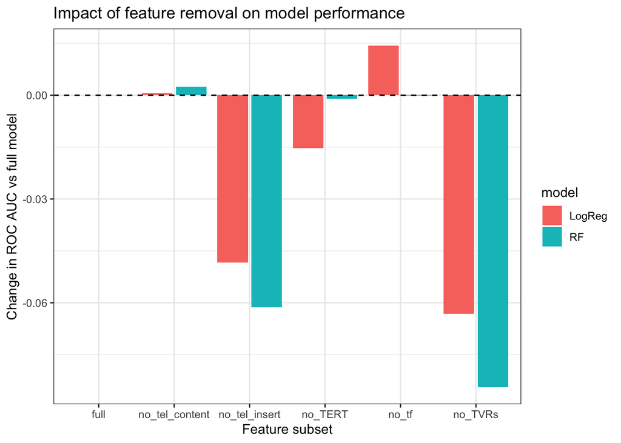

```r
ggplot(results, aes(x = feature_set, y = delta_AUC, fill = model)) +
  geom_col(position = position_dodge2()) +
  geom_hline(yintercept = 0, linetype = "dashed") +
  labs(
    x = "Feature subset",
    y = "Change in ROC AUC vs full model",
    title = "Impact of feature removal on model performance"
  ) +
  theme_bw()
```

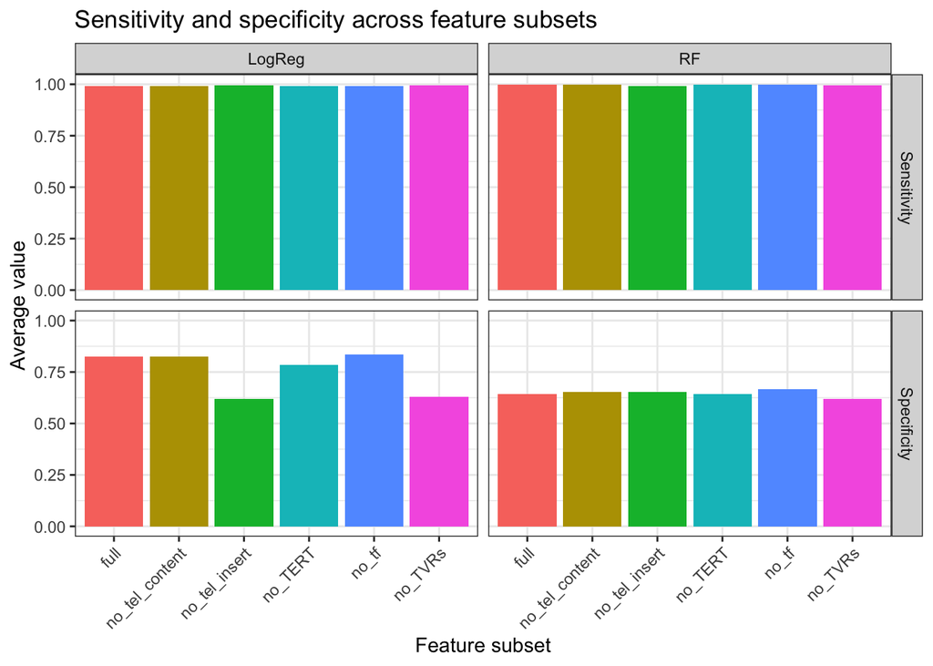

```r
results_long <- results %>%
  select(feature_set, model, mean_sensitivity, mean_specificity) %>%
  pivot_longer(
    cols = c(mean_sensitivity, mean_specificity),
    names_to = "metric",
    values_to = "value"
  ) %>%
  mutate(
    metric = recode(
      metric,
      mean_sensitivity = "Sensitivity",
      mean_specificity = "Specificity"
    )
  )

ggplot(results_long, aes(x = feature_set, y = value, fill = feature_set)) +
  geom_col(show.legend = FALSE) +
  labs(
    x = "Feature subset",
    y = "Average value",
    title = "Sensitivity and specificity across feature subsets"
  ) +
  theme_bw() +
  facet_grid(metric ~ model)+
  theme(axis.text.x = element_text(angle = 45, hjust = 1))
```

**Removing TVR motif** features causes the **largest performance decrease** in both models, particularly for Random Forest, suggesting that telomere variant repeat composition contains strong predictive information for ALT status. **Removing telomere insertion rate** also **noticeably reduces performance**.

Of course, **when removing TVR motifs we are removing 9 individual features instead of one**, and thus an abrupt decrease in performance can be expected. Although informative on TVR motifs contribution to classification, **the comparison is not fair**. What could be interesting is to perform a **LOFO on each individual TVR motif**, looking for the ones having more discriminatory power.